# Risk Factor Analysis

## Outcome Variable

**Outcome Variable:** ever_co

## Predictor Variables

**Intervention Variable:** mage

**Adjustment Set:**

- arm
- meducyrs
- feducyrs
- W_mhtcm
- single
- delta_meducyrs
- delta_feducyrs
- delta_W_mhtcm
- delta_single

## Stratifying Variables

The analysis was stratified on these variable(s):

- agecat
- studyid
- country

## Data Summary

| agecat | studyid | country | mage | ever_co | n_cell | n |
| --- | --- | --- | --- | --- | --- | --- |
| 0-24 months | ki0047075b-MAL-ED | BANGLADESH | [20-30) | 0 | 161 | 263 |
| 0-24 months | ki0047075b-MAL-ED | BANGLADESH | [20-30) | 1 | 19 | 263 |
| 0-24 months | ki0047075b-MAL-ED | BANGLADESH | <20 | 0 | 27 | 263 |
| 0-24 months | ki0047075b-MAL-ED | BANGLADESH | <20 | 1 | 10 | 263 |
| 0-24 months | ki0047075b-MAL-ED | BANGLADESH | >=30 | 0 | 36 | 263 |
| 0-24 months | ki0047075b-MAL-ED | BANGLADESH | >=30 | 1 | 10 | 263 |
| 0-24 months | ki0047075b-MAL-ED | BRAZIL | [20-30) | 0 | 138 | 233 |
| 0-24 months | ki0047075b-MAL-ED | BRAZIL | [20-30) | 1 | 1 | 233 |
| 0-24 months | ki0047075b-MAL-ED | BRAZIL | <20 | 0 | 43 | 233 |
| 0-24 months | ki0047075b-MAL-ED | BRAZIL | <20 | 1 | 0 | 233 |
| 0-24 months | ki0047075b-MAL-ED | BRAZIL | >=30 | 0 | 50 | 233 |
| 0-24 months | ki0047075b-MAL-ED | BRAZIL | >=30 | 1 | 1 | 233 |
| 0-24 months | ki0047075b-MAL-ED | INDIA | [20-30) | 0 | 152 | 249 |
| 0-24 months | ki0047075b-MAL-ED | INDIA | [20-30) | 1 | 42 | 249 |
| 0-24 months | ki0047075b-MAL-ED | INDIA | <20 | 0 | 23 | 249 |
| 0-24 months | ki0047075b-MAL-ED | INDIA | <20 | 1 | 11 | 249 |
| 0-24 months | ki0047075b-MAL-ED | INDIA | >=30 | 0 | 21 | 249 |
| 0-24 months | ki0047075b-MAL-ED | INDIA | >=30 | 1 | 0 | 249 |
| 0-24 months | ki0047075b-MAL-ED | NEPAL | [20-30) | 0 | 174 | 240 |
| 0-24 months | ki0047075b-MAL-ED | NEPAL | [20-30) | 1 | 15 | 240 |
| 0-24 months | ki0047075b-MAL-ED | NEPAL | <20 | 0 | 3 | 240 |
| 0-24 months | ki0047075b-MAL-ED | NEPAL | <20 | 1 | 2 | 240 |
| 0-24 months | ki0047075b-MAL-ED | NEPAL | >=30 | 0 | 42 | 240 |
| 0-24 months | ki0047075b-MAL-ED | NEPAL | >=30 | 1 | 4 | 240 |
| 0-24 months | ki0047075b-MAL-ED | PERU | [20-30) | 0 | 149 | 302 |
| 0-24 months | ki0047075b-MAL-ED | PERU | [20-30) | 1 | 4 | 302 |
| 0-24 months | ki0047075b-MAL-ED | PERU | <20 | 0 | 77 | 302 |
| 0-24 months | ki0047075b-MAL-ED | PERU | <20 | 1 | 5 | 302 |
| 0-24 months | ki0047075b-MAL-ED | PERU | >=30 | 0 | 64 | 302 |
| 0-24 months | ki0047075b-MAL-ED | PERU | >=30 | 1 | 3 | 302 |

[output cut: 450 more lines]

The following strata were considered:

- agecat: 0-24 months, studyid: ki0047075b-MAL-ED, country: BANGLADESH
- agecat: 0-24 months, studyid: ki0047075b-MAL-ED, country: BRAZIL
- agecat: 0-24 months, studyid: ki0047075b-MAL-ED, country: INDIA
- agecat: 0-24 months, studyid: ki0047075b-MAL-ED, country: NEPAL
- agecat: 0-24 months, studyid: ki0047075b-MAL-ED, country: PERU
- agecat: 0-24 months, studyid: ki0047075b-MAL-ED, country: SOUTH AFRICA
- agecat: 0-24 months, studyid: ki0047075b-MAL-ED, country: TANZANIA, UNITED REPUBLIC OF
- agecat: 0-24 months, studyid: ki1000108-CMC-V-BCS-2002, country: INDIA
- agecat: 0-24 months, studyid: ki1000108-IRC, country: INDIA
- agecat: 0-24 months, studyid: ki1000109-EE, country: PAKISTAN
- agecat: 0-24 months, studyid: ki1000304b-SAS-CompFeed, country: INDIA
- agecat: 0-24 months, studyid: ki1000304b-SAS-FoodSuppl, country: INDIA
- agecat: 0-24 months, studyid: ki1017093-NIH-Birth, country: BANGLADESH
- agecat: 0-24 months, studyid: ki1017093b-PROVIDE, country: BANGLADESH
- agecat: 0-24 months, studyid: ki1017093c-NIH-Crypto, country: BANGLADESH
- agecat: 0-24 months, studyid: ki1066203-TanzaniaChild2, country: TANZANIA, UNITED REPUBLIC OF
- agecat: 0-24 months, studyid: ki1101329-Keneba, country: GAMBIA
- agecat: 0-24 months, studyid: ki1112895-Guatemala BSC, country: GUATEMALA
- agecat: 0-24 months, studyid: ki1112895-iLiNS-Zinc, country: BURKINA FASO
- agecat: 0-24 months, studyid: ki1113344-GMS-Nepal, country: NEPAL
- agecat: 0-24 months, studyid: ki1119695-PROBIT, country: BELARUS
- agecat: 0-24 months, studyid: ki1126311-ZVITAMBO, country: ZIMBABWE
- agecat: 0-24 months, studyid: ki1135781-COHORTS, country: GUATEMALA
- agecat: 0-24 months, studyid: ki1135781-COHORTS, country: INDIA
- agecat: 0-24 months, studyid: ki1135781-COHORTS, country: PHILIPPINES
- agecat: 0-24 months, studyid: ki1148112-LCNI-5, country: MALAWI
- agecat: 0-24 months, studyid: kiGH5241-JiVitA-3, country: BANGLADESH
- agecat: 0-6 months, studyid: ki0047075b-MAL-ED, country: BANGLADESH
- agecat: 0-6 months, studyid: ki0047075b-MAL-ED, country: BRAZIL
- agecat: 0-6 months, studyid: ki0047075b-MAL-ED, country: INDIA
- agecat: 0-6 months, studyid: ki0047075b-MAL-ED, country: NEPAL
- agecat: 0-6 months, studyid: ki0047075b-MAL-ED, country: PERU
- agecat: 0-6 months, studyid: ki0047075b-MAL-ED, country: SOUTH AFRICA
- agecat: 0-6 months, studyid: ki0047075b-MAL-ED, country: TANZANIA, UNITED REPUBLIC OF
- agecat: 0-6 months, studyid: ki1000108-CMC-V-BCS-2002, country: INDIA
- agecat: 0-6 months, studyid: ki1000108-IRC, country: INDIA
- agecat: 0-6 months, studyid: ki1000109-EE, country: PAKISTAN
- agecat: 0-6 months, studyid: ki1000304b-SAS-CompFeed, country: INDIA
- agecat: 0-6 months, studyid: ki1000304b-SAS-FoodSuppl, country: INDIA
- agecat: 0-6 months, studyid: ki1017093-NIH-Birth, country: BANGLADESH
- agecat: 0-6 months, studyid: ki1017093b-PROVIDE, country: BANGLADESH
- agecat: 0-6 months, studyid: ki1017093c-NIH-Crypto, country: BANGLADESH
- agecat: 0-6 months, studyid: ki1066203-TanzaniaChild2, country: TANZANIA, UNITED REPUBLIC OF
- agecat: 0-6 months, studyid: ki1101329-Keneba, country: GAMBIA
- agecat: 0-6 months, studyid: ki1112895-Guatemala BSC, country: GUATEMALA
- agecat: 0-6 months, studyid: ki1113344-GMS-Nepal, country: NEPAL
- agecat: 0-6 months, studyid: ki1119695-PROBIT, country: BELARUS
- agecat: 0-6 months, studyid: ki1126311-ZVITAMBO, country: ZIMBABWE
- agecat: 0-6 months, studyid: ki1135781-COHORTS, country: GUATEMALA
- agecat: 0-6 months, studyid: ki1135781-COHORTS, country: INDIA
- agecat: 0-6 months, studyid: ki1135781-COHORTS, country: PHILIPPINES
- agecat: 0-6 months, studyid: ki1148112-LCNI-5, country: MALAWI
- agecat: 0-6 months, studyid: kiGH5241-JiVitA-3, country: BANGLADESH
- agecat: 6-24 months, studyid: ki0047075b-MAL-ED, country: BANGLADESH
- agecat: 6-24 months, studyid: ki0047075b-MAL-ED, country: BRAZIL
- agecat: 6-24 months, studyid: ki0047075b-MAL-ED, country: INDIA
- agecat: 6-24 months, studyid: ki0047075b-MAL-ED, country: NEPAL
- agecat: 6-24 months, studyid: ki0047075b-MAL-ED, country: PERU
- agecat: 6-24 months, studyid: ki0047075b-MAL-ED, country: SOUTH AFRICA
- agecat: 6-24 months, studyid: ki0047075b-MAL-ED, country: TANZANIA, UNITED REPUBLIC OF
- agecat: 6-24 months, studyid: ki1000108-CMC-V-BCS-2002, country: INDIA
- agecat: 6-24 months, studyid: ki1000108-IRC, country: INDIA
- agecat: 6-24 months, studyid: ki1000109-EE, country: PAKISTAN
- agecat: 6-24 months, studyid: ki1000304b-SAS-CompFeed, country: INDIA
- agecat: 6-24 months, studyid: ki1000304b-SAS-FoodSuppl, country: INDIA
- agecat: 6-24 months, studyid: ki1017093-NIH-Birth, country: BANGLADESH
- agecat: 6-24 months, studyid: ki1017093b-PROVIDE, country: BANGLADESH
- agecat: 6-24 months, studyid: ki1017093c-NIH-Crypto, country: BANGLADESH
- agecat: 6-24 months, studyid: ki1066203-TanzaniaChild2, country: TANZANIA, UNITED REPUBLIC OF
- agecat: 6-24 months, studyid: ki1101329-Keneba, country: GAMBIA
- agecat: 6-24 months, studyid: ki1112895-Guatemala BSC, country: GUATEMALA
- agecat: 6-24 months, studyid: ki1112895-iLiNS-Zinc, country: BURKINA FASO
- agecat: 6-24 months, studyid: ki1113344-GMS-Nepal, country: NEPAL
- agecat: 6-24 months, studyid: ki1119695-PROBIT, country: BELARUS
- agecat: 6-24 months, studyid: ki1126311-ZVITAMBO, country: ZIMBABWE
- agecat: 6-24 months, studyid: ki1135781-COHORTS, country: GUATEMALA
- agecat: 6-24 months, studyid: ki1135781-COHORTS, country: INDIA
- agecat: 6-24 months, studyid: ki1135781-COHORTS, country: PHILIPPINES
- agecat: 6-24 months, studyid: ki1148112-LCNI-5, country: MALAWI
- agecat: 6-24 months, studyid: kiGH5241-JiVitA-3, country: BANGLADESH

### Dropped Strata

Some strata were dropped due to rare outcomes:

- agecat: 0-24 months, studyid: ki0047075b-MAL-ED, country: BRAZIL
- agecat: 0-24 months, studyid: ki0047075b-MAL-ED, country: INDIA
- agecat: 0-24 months, studyid: ki0047075b-MAL-ED, country: NEPAL
- agecat: 0-24 months, studyid: ki0047075b-MAL-ED, country: PERU
- agecat: 0-24 months, studyid: ki0047075b-MAL-ED, country: SOUTH AFRICA
- agecat: 0-24 months, studyid: ki0047075b-MAL-ED, country: TANZANIA, UNITED REPUBLIC OF
- agecat: 0-24 months, studyid: ki1000109-EE, country: PAKISTAN
- agecat: 0-24 months, studyid: ki1119695-PROBIT, country: BELARUS
- agecat: 0-6 months, studyid: ki0047075b-MAL-ED, country: BANGLADESH
- agecat: 0-6 months, studyid: ki0047075b-MAL-ED, country: BRAZIL
- agecat: 0-6 months, studyid: ki0047075b-MAL-ED, country: INDIA
- agecat: 0-6 months, studyid: ki0047075b-MAL-ED, country: NEPAL
- agecat: 0-6 months, studyid: ki0047075b-MAL-ED, country: PERU
- agecat: 0-6 months, studyid: ki0047075b-MAL-ED, country: SOUTH AFRICA
- agecat: 0-6 months, studyid: ki0047075b-MAL-ED, country: TANZANIA, UNITED REPUBLIC OF
- agecat: 0-6 months, studyid: ki1000108-CMC-V-BCS-2002, country: INDIA
- agecat: 0-6 months, studyid: ki1000108-IRC, country: INDIA
- agecat: 0-6 months, studyid: ki1000109-EE, country: PAKISTAN
- agecat: 0-6 months, studyid: ki1000304b-SAS-FoodSuppl, country: INDIA
- agecat: 0-6 months, studyid: ki1017093-NIH-Birth, country: BANGLADESH
- agecat: 0-6 months, studyid: ki1017093b-PROVIDE, country: BANGLADESH
- agecat: 0-6 months, studyid: ki1017093c-NIH-Crypto, country: BANGLADESH
- agecat: 0-6 months, studyid: ki1066203-TanzaniaChild2, country: TANZANIA, UNITED REPUBLIC OF
- agecat: 0-6 months, studyid: ki1112895-Guatemala BSC, country: GUATEMALA
- agecat: 0-6 months, studyid: ki1119695-PROBIT, country: BELARUS
- agecat: 0-6 months, studyid: ki1135781-COHORTS, country: GUATEMALA
- agecat: 0-6 months, studyid: ki1148112-LCNI-5, country: MALAWI
- agecat: 6-24 months, studyid: ki0047075b-MAL-ED, country: BRAZIL
- agecat: 6-24 months, studyid: ki0047075b-MAL-ED, country: INDIA
- agecat: 6-24 months, studyid: ki0047075b-MAL-ED, country: NEPAL
- agecat: 6-24 months, studyid: ki0047075b-MAL-ED, country: PERU
- agecat: 6-24 months, studyid: ki0047075b-MAL-ED, country: SOUTH AFRICA
- agecat: 6-24 months, studyid: ki0047075b-MAL-ED, country: TANZANIA, UNITED REPUBLIC OF
- agecat: 6-24 months, studyid: ki1000109-EE, country: PAKISTAN
- agecat: 6-24 months, studyid: ki1112895-Guatemala BSC, country: GUATEMALA
- agecat: 6-24 months, studyid: ki1119695-PROBIT, country: BELARUS

## Methods Detail

We’re interested in the causal parameters $E[Y_a]$ for all values of $a \in \mathcal{A}$. These parameters represent the mean outcome if, possibly contrary to fact, we intervened to set all units to have $A=a$. Under the randomization and positivity assumptions, these are identified by the statistical parameters $\psi_a=E_W[E_{Y|A,W}(Y|A=a,W)]$. In addition, we’re interested in the mean of $Y$, $E[Y]$ under no intervention (the observed mean). We will estimate these parameters by using SuperLearner to fit the relevant likelihood factors – $E_{Y|A,W}(Y|A=a,W)$ and $p(A=a|W)$, and then updating our likelihood fit using a joint TMLE.

For unadjusted analyses ($W=\{\}$), initial likelihoods were estimated using Lrnr_glm to estimate the simple $E(Y|A)$ and Lrnr_mean to estimate $p(A)$. For adjusted analyses, a small library containing Lrnr_glmnet, Lrnr_xgboost, and Lrnr_mean was used.

Having estimated these parameters, we will then use the delta method to estimate relative risks and attributable risks relative to a prespecified baseline level of $A$.

# Results Detail

## Results Plots

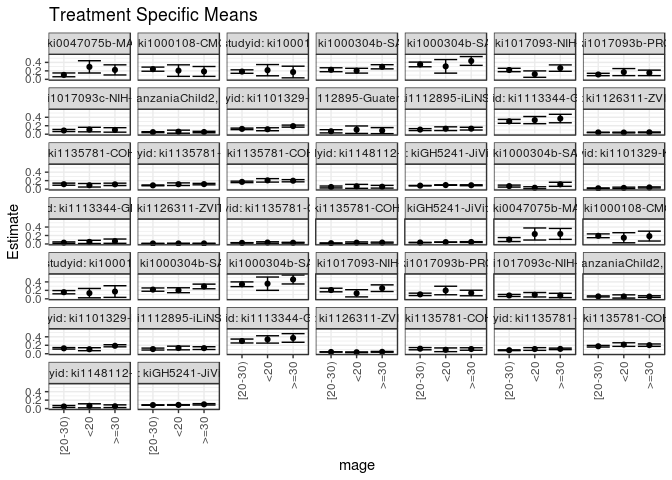

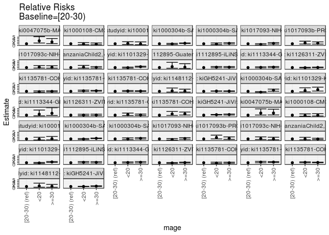

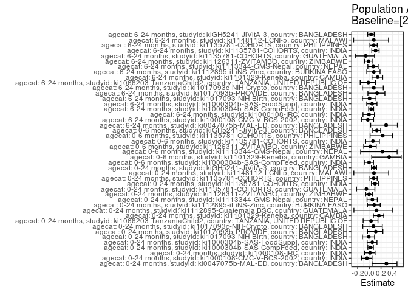

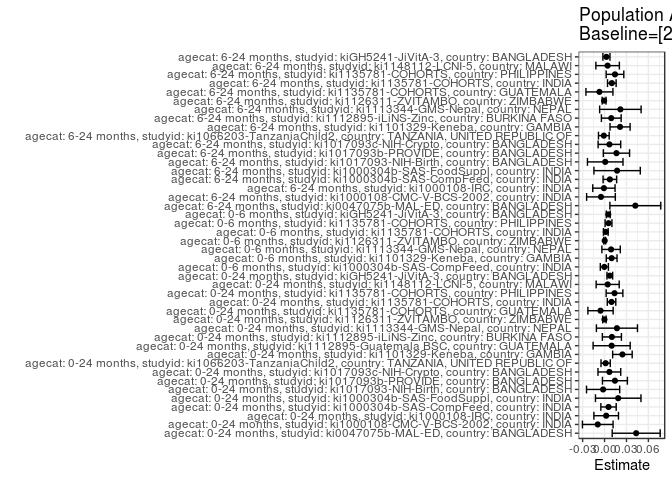

## Results Table

### Parameter: TSM

| agecat | studyid | country | intervention_level | baseline_level | estimate | ci_lower | ci_upper |
| --- | --- | --- | --- | --- | --- | --- | --- |
| 0-24 months | ki0047075b-MAL-ED | BANGLADESH | [20-30) | NA | 0.1049631 | 0.0600631 | 0.1498631 |
| 0-24 months | ki0047075b-MAL-ED | BANGLADESH | <20 | NA | 0.2943268 | 0.1493810 | 0.4392726 |
| 0-24 months | ki0047075b-MAL-ED | BANGLADESH | >=30 | NA | 0.2227589 | 0.1031424 | 0.3423753 |
| 0-24 months | ki1000108-CMC-V-BCS-2002 | INDIA | [20-30) | NA | 0.2398649 | 0.1911553 | 0.2885744 |
| 0-24 months | ki1000108-CMC-V-BCS-2002 | INDIA | <20 | NA | 0.2058824 | 0.0697869 | 0.3419778 |
| 0-24 months | ki1000108-CMC-V-BCS-2002 | INDIA | >=30 | NA | 0.1860465 | 0.0695783 | 0.3025147 |
| 0-24 months | ki1000108-IRC | INDIA | [20-30) | NA | 0.1831395 | 0.1422168 | 0.2240622 |
| 0-24 months | ki1000108-IRC | INDIA | <20 | NA | 0.2162162 | 0.0834096 | 0.3490229 |
| 0-24 months | ki1000108-IRC | INDIA | >=30 | NA | 0.1724138 | 0.0347651 | 0.3100625 |
| 0-24 months | ki1000304b-SAS-CompFeed | INDIA | [20-30) | NA | 0.2265503 | 0.1800413 | 0.2730593 |
| 0-24 months | ki1000304b-SAS-CompFeed | INDIA | <20 | NA | 0.2038181 | 0.1466781 | 0.2609581 |
| 0-24 months | ki1000304b-SAS-CompFeed | INDIA | >=30 | NA | 0.2964742 | 0.2471309 | 0.3458175 |
| 0-24 months | ki1000304b-SAS-FoodSuppl | INDIA | [20-30) | NA | 0.3521006 | 0.2970032 | 0.4071979 |
| 0-24 months | ki1000304b-SAS-FoodSuppl | INDIA | <20 | NA | 0.3065764 | 0.1462519 | 0.4669008 |
| 0-24 months | ki1000304b-SAS-FoodSuppl | INDIA | >=30 | NA | 0.4334913 | 0.3297108 | 0.5372717 |
| 0-24 months | ki1017093-NIH-Birth | BANGLADESH | [20-30) | NA | 0.2206235 | 0.1807918 | 0.2604552 |
| 0-24 months | ki1017093-NIH-Birth | BANGLADESH | <20 | NA | 0.1232877 | 0.0478090 | 0.1987664 |
| 0-24 months | ki1017093-NIH-Birth | BANGLADESH | >=30 | NA | 0.2651515 | 0.1897888 | 0.3405142 |
| 0-24 months | ki1017093b-PROVIDE | BANGLADESH | [20-30) | NA | 0.1143762 | 0.0864445 | 0.1423080 |
| 0-24 months | ki1017093b-PROVIDE | BANGLADESH | <20 | NA | 0.1705272 | 0.0870089 | 0.2540454 |
| 0-24 months | ki1017093b-PROVIDE | BANGLADESH | >=30 | NA | 0.1524071 | 0.0877342 | 0.2170800 |
| 0-24 months | ki1017093c-NIH-Crypto | BANGLADESH | [20-30) | NA | 0.0870983 | 0.0622033 | 0.1119933 |
| 0-24 months | ki1017093c-NIH-Crypto | BANGLADESH | <20 | NA | 0.1097696 | 0.0565501 | 0.1629891 |
| 0-24 months | ki1017093c-NIH-Crypto | BANGLADESH | >=30 | NA | 0.1012112 | 0.0483455 | 0.1540769 |
| 0-24 months | ki1066203-TanzaniaChild2 | TANZANIA, UNITED REPUBLIC OF | [20-30) | NA | 0.0485964 | 0.0379218 | 0.0592710 |
| 0-24 months | ki1066203-TanzaniaChild2 | TANZANIA, UNITED REPUBLIC OF | <20 | NA | 0.0595591 | 0.0237100 | 0.0954081 |
| 0-24 months | ki1066203-TanzaniaChild2 | TANZANIA, UNITED REPUBLIC OF | >=30 | NA | 0.0517812 | 0.0346423 | 0.0689201 |
| 0-24 months | ki1101329-Keneba | GAMBIA | [20-30) | NA | 0.1257435 | 0.1082198 | 0.1432672 |
| 0-24 months | ki1101329-Keneba | GAMBIA | <20 | NA | 0.1172449 | 0.0820792 | 0.1524106 |
| 0-24 months | ki1101329-Keneba | GAMBIA | >=30 | NA | 0.1913673 | 0.1672350 | 0.2154997 |

[output cut: 102 more lines]

### Parameter: E(Y)

| agecat | studyid | country | intervention_level | baseline_level | estimate | ci_lower | ci_upper |
| --- | --- | --- | --- | --- | --- | --- | --- |
| 0-24 months | ki0047075b-MAL-ED | BANGLADESH | NA | NA | 0.1482890 | 0.1052563 | 0.1913216 |
| 0-24 months | ki1000108-CMC-V-BCS-2002 | INDIA | NA | NA | 0.2305630 | 0.1877616 | 0.2733644 |
| 0-24 months | ki1000108-IRC | INDIA | NA | NA | 0.1853659 | 0.1477057 | 0.2230261 |
| 0-24 months | ki1000304b-SAS-CompFeed | INDIA | NA | NA | 0.2319894 | 0.1917264 | 0.2722524 |
| 0-24 months | ki1000304b-SAS-FoodSuppl | INDIA | NA | NA | 0.3708134 | 0.3244530 | 0.4171738 |
| 0-24 months | ki1017093-NIH-Birth | BANGLADESH | NA | NA | 0.2186495 | 0.1861408 | 0.2511582 |
| 0-24 months | ki1017093b-PROVIDE | BANGLADESH | NA | NA | 0.1285714 | 0.1037574 | 0.1533855 |
| 0-24 months | ki1017093c-NIH-Crypto | BANGLADESH | NA | NA | 0.0936675 | 0.0729118 | 0.1144233 |
| 0-24 months | ki1066203-TanzaniaChild2 | TANZANIA, UNITED REPUBLIC OF | NA | NA | 0.0500842 | 0.0413120 | 0.0588564 |
| 0-24 months | ki1101329-Keneba | GAMBIA | NA | NA | 0.1502101 | 0.1371047 | 0.1633155 |
| 0-24 months | ki1112895-Guatemala BSC | GUATEMALA | NA | NA | 0.0782918 | 0.0468271 | 0.1097565 |
| 0-24 months | ki1112895-iLiNS-Zinc | BURKINA FASO | NA | NA | 0.1192949 | 0.0996089 | 0.1389809 |
| 0-24 months | ki1113344-GMS-Nepal | NEPAL | NA | NA | 0.3205980 | 0.2832855 | 0.3579105 |
| 0-24 months | ki1126311-ZVITAMBO | ZIMBABWE | NA | NA | 0.0418076 | 0.0384798 | 0.0451354 |
| 0-24 months | ki1135781-COHORTS | GUATEMALA | NA | NA | 0.1103654 | 0.0935883 | 0.1271425 |
| 0-24 months | ki1135781-COHORTS | INDIA | NA | NA | 0.0980577 | 0.0900528 | 0.1060627 |
| 0-24 months | ki1135781-COHORTS | PHILIPPINES | NA | NA | 0.1839080 | 0.1701456 | 0.1976705 |
| 0-24 months | ki1148112-LCNI-5 | MALAWI | NA | NA | 0.0537313 | 0.0366447 | 0.0708180 |
| 0-24 months | kiGH5241-JiVitA-3 | BANGLADESH | NA | NA | 0.0885347 | 0.0846552 | 0.0924142 |
| 0-6 months | ki1000304b-SAS-CompFeed | INDIA | NA | NA | 0.0704787 | 0.0478990 | 0.0930584 |
| 0-6 months | ki1101329-Keneba | GAMBIA | NA | NA | 0.0286188 | 0.0219621 | 0.0352756 |
| 0-6 months | ki1113344-GMS-Nepal | NEPAL | NA | NA | 0.0398671 | 0.0242254 | 0.0555088 |
| 0-6 months | ki1126311-ZVITAMBO | ZIMBABWE | NA | NA | 0.0120997 | 0.0102756 | 0.0139237 |
| 0-6 months | ki1135781-COHORTS | INDIA | NA | NA | 0.0274456 | 0.0229617 | 0.0319295 |
| 0-6 months | ki1135781-COHORTS | PHILIPPINES | NA | NA | 0.0236531 | 0.0182537 | 0.0290525 |
| 0-6 months | kiGH5241-JiVitA-3 | BANGLADESH | NA | NA | 0.0393898 | 0.0369053 | 0.0418742 |
| 6-24 months | ki0047075b-MAL-ED | BANGLADESH | NA | NA | 0.1464435 | 0.1015265 | 0.1913605 |
| 6-24 months | ki1000108-CMC-V-BCS-2002 | INDIA | NA | NA | 0.1876676 | 0.1479906 | 0.2273445 |
| 6-24 months | ki1000108-IRC | INDIA | NA | NA | 0.1560976 | 0.1209228 | 0.1912723 |
| 6-24 months | ki1000304b-SAS-CompFeed | INDIA | NA | NA | 0.2260619 | 0.1909133 | 0.2612105 |
| 6-24 months | ki1000304b-SAS-FoodSuppl | INDIA | NA | NA | 0.3615960 | 0.3145115 | 0.4086805 |
| 6-24 months | ki1017093-NIH-Birth | BANGLADESH | NA | NA | 0.2092593 | 0.1749182 | 0.2436003 |
| 6-24 months | ki1017093b-PROVIDE | BANGLADESH | NA | NA | 0.1221498 | 0.0962275 | 0.1480722 |
| 6-24 months | ki1017093c-NIH-Crypto | BANGLADESH | NA | NA | 0.0863014 | 0.0659171 | 0.1066856 |
| 6-24 months | ki1066203-TanzaniaChild2 | TANZANIA, UNITED REPUBLIC OF | NA | NA | 0.0564436 | 0.0463321 | 0.0665551 |
| 6-24 months | ki1101329-Keneba | GAMBIA | NA | NA | 0.1489203 | 0.1354543 | 0.1623863 |
| 6-24 months | ki1112895-iLiNS-Zinc | BURKINA FASO | NA | NA | 0.1192949 | 0.0996089 | 0.1389809 |
| 6-24 months | ki1113344-GMS-Nepal | NEPAL | NA | NA | 0.3220339 | 0.2842988 | 0.3597690 |
| 6-24 months | ki1126311-ZVITAMBO | ZIMBABWE | NA | NA | 0.0406862 | 0.0369369 | 0.0444355 |
| 6-24 months | ki1135781-COHORTS | GUATEMALA | NA | NA | 0.1123039 | 0.0945135 | 0.1300943 |
| 6-24 months | ki1135781-COHORTS | INDIA | NA | NA | 0.0928355 | 0.0847544 | 0.1009166 |
| 6-24 months | ki1135781-COHORTS | PHILIPPINES | NA | NA | 0.1908832 | 0.1763448 | 0.2054216 |
| 6-24 months | ki1148112-LCNI-5 | MALAWI | NA | NA | 0.0546282 | 0.0372644 | 0.0719920 |
| 6-24 months | kiGH5241-JiVitA-3 | BANGLADESH | NA | NA | 0.0868936 | 0.0822329 | 0.0915543 |

### Parameter: RR

| agecat | studyid | country | intervention_level | baseline_level | estimate | ci_lower | ci_upper |
| --- | --- | --- | --- | --- | --- | --- | --- |
| 0-24 months | ki0047075b-MAL-ED | BANGLADESH | [20-30) | [20-30) | 1.0000000 | 1.0000000 | 1.0000000 |
| 0-24 months | ki0047075b-MAL-ED | BANGLADESH | <20 | [20-30) | 2.8040985 | 1.4675679 | 5.3578225 |
| 0-24 months | ki0047075b-MAL-ED | BANGLADESH | >=30 | [20-30) | 2.1222590 | 1.0745538 | 4.1914918 |
| 0-24 months | ki1000108-CMC-V-BCS-2002 | INDIA | [20-30) | [20-30) | 1.0000000 | 1.0000000 | 1.0000000 |
| 0-24 months | ki1000108-CMC-V-BCS-2002 | INDIA | <20 | [20-30) | 0.8583264 | 0.4298605 | 1.7138681 |
| 0-24 months | ki1000108-CMC-V-BCS-2002 | INDIA | >=30 | [20-30) | 0.7756305 | 0.4016362 | 1.4978796 |
| 0-24 months | ki1000108-IRC | INDIA | [20-30) | [20-30) | 1.0000000 | 1.0000000 | 1.0000000 |
| 0-24 months | ki1000108-IRC | INDIA | <20 | [20-30) | 1.1806092 | 0.6141094 | 2.2696901 |
| 0-24 months | ki1000108-IRC | INDIA | >=30 | [20-30) | 0.9414340 | 0.4109046 | 2.1569435 |
| 0-24 months | ki1000304b-SAS-CompFeed | INDIA | [20-30) | [20-30) | 1.0000000 | 1.0000000 | 1.0000000 |
| 0-24 months | ki1000304b-SAS-CompFeed | INDIA | <20 | [20-30) | 0.8996595 | 0.6456289 | 1.2536416 |
| 0-24 months | ki1000304b-SAS-CompFeed | INDIA | >=30 | [20-30) | 1.3086463 | 1.1357942 | 1.5078041 |
| 0-24 months | ki1000304b-SAS-FoodSuppl | INDIA | [20-30) | [20-30) | 1.0000000 | 1.0000000 | 1.0000000 |
| 0-24 months | ki1000304b-SAS-FoodSuppl | INDIA | <20 | [20-30) | 0.8707068 | 0.5048639 | 1.5016530 |
| 0-24 months | ki1000304b-SAS-FoodSuppl | INDIA | >=30 | [20-30) | 1.2311576 | 0.9249268 | 1.6387771 |
| 0-24 months | ki1017093-NIH-Birth | BANGLADESH | [20-30) | [20-30) | 1.0000000 | 1.0000000 | 1.0000000 |
| 0-24 months | ki1017093-NIH-Birth | BANGLADESH | <20 | [20-30) | 0.5588148 | 0.2951655 | 1.0579624 |
| 0-24 months | ki1017093-NIH-Birth | BANGLADESH | >=30 | [20-30) | 1.2018281 | 0.8582375 | 1.6829732 |
| 0-24 months | ki1017093b-PROVIDE | BANGLADESH | [20-30) | [20-30) | 1.0000000 | 1.0000000 | 1.0000000 |
| 0-24 months | ki1017093b-PROVIDE | BANGLADESH | <20 | [20-30) | 1.4909318 | 0.8629095 | 2.5760264 |
| 0-24 months | ki1017093b-PROVIDE | BANGLADESH | >=30 | [20-30) | 1.3325067 | 0.8182598 | 2.1699391 |
| 0-24 months | ki1017093c-NIH-Crypto | BANGLADESH | [20-30) | [20-30) | 1.0000000 | 1.0000000 | 1.0000000 |
| 0-24 months | ki1017093c-NIH-Crypto | BANGLADESH | <20 | [20-30) | 1.2602956 | 0.7182344 | 2.2114574 |
| 0-24 months | ki1017093c-NIH-Crypto | BANGLADESH | >=30 | [20-30) | 1.1620342 | 0.6408881 | 2.1069565 |
| 0-24 months | ki1066203-TanzaniaChild2 | TANZANIA, UNITED REPUBLIC OF | [20-30) | [20-30) | 1.0000000 | 1.0000000 | 1.0000000 |
| 0-24 months | ki1066203-TanzaniaChild2 | TANZANIA, UNITED REPUBLIC OF | <20 | [20-30) | 1.2255856 | 0.6458616 | 2.3256686 |
| 0-24 months | ki1066203-TanzaniaChild2 | TANZANIA, UNITED REPUBLIC OF | >=30 | [20-30) | 1.0655356 | 0.7161701 | 1.5853303 |
| 0-24 months | ki1101329-Keneba | GAMBIA | [20-30) | [20-30) | 1.0000000 | 1.0000000 | 1.0000000 |
| 0-24 months | ki1101329-Keneba | GAMBIA | <20 | [20-30) | 0.9324132 | 0.6700426 | 1.2975209 |
| 0-24 months | ki1101329-Keneba | GAMBIA | >=30 | [20-30) | 1.5218860 | 1.2618700 | 1.8354798 |

[output cut: 102 more lines]

### Parameter: PAR

| agecat | studyid | country | intervention_level | baseline_level | estimate | ci_lower | ci_upper |
| --- | --- | --- | --- | --- | --- | --- | --- |
| 0-24 months | ki0047075b-MAL-ED | BANGLADESH | [20-30) | NA | 0.0433259 | 0.0104870 | 0.0761648 |
| 0-24 months | ki1000108-CMC-V-BCS-2002 | INDIA | [20-30) | NA | -0.0093019 | -0.0302523 | 0.0116486 |
| 0-24 months | ki1000108-IRC | INDIA | [20-30) | NA | 0.0022263 | -0.0145899 | 0.0190425 |
| 0-24 months | ki1000304b-SAS-CompFeed | INDIA | [20-30) | NA | 0.0054391 | -0.0050696 | 0.0159479 |
| 0-24 months | ki1000304b-SAS-FoodSuppl | INDIA | [20-30) | NA | 0.0187128 | -0.0124276 | 0.0498533 |
| 0-24 months | ki1017093-NIH-Birth | BANGLADESH | [20-30) | NA | -0.0019740 | -0.0246909 | 0.0207429 |
| 0-24 months | ki1017093b-PROVIDE | BANGLADESH | [20-30) | NA | 0.0141952 | -0.0028724 | 0.0312628 |
| 0-24 months | ki1017093c-NIH-Crypto | BANGLADESH | [20-30) | NA | 0.0065692 | -0.0090024 | 0.0221409 |
| 0-24 months | ki1066203-TanzaniaChild2 | TANZANIA, UNITED REPUBLIC OF | [20-30) | NA | 0.0014878 | -0.0048505 | 0.0078261 |
| 0-24 months | ki1101329-Keneba | GAMBIA | [20-30) | NA | 0.0244665 | 0.0111131 | 0.0378200 |
| 0-24 months | ki1112895-Guatemala BSC | GUATEMALA | [20-30) | NA | 0.0097204 | -0.0156673 | 0.0351081 |
| 0-24 months | ki1112895-iLiNS-Zinc | BURKINA FASO | [20-30) | NA | 0.0100382 | -0.0030078 | 0.0230842 |
| 0-24 months | ki1113344-GMS-Nepal | NEPAL | [20-30) | NA | 0.0169476 | -0.0111540 | 0.0450493 |
| 0-24 months | ki1126311-ZVITAMBO | ZIMBABWE | [20-30) | NA | -0.0001438 | -0.0024941 | 0.0022066 |
| 0-24 months | ki1135781-COHORTS | GUATEMALA | [20-30) | NA | -0.0055061 | -0.0227878 | 0.0117757 |
| 0-24 months | ki1135781-COHORTS | INDIA | [20-30) | NA | 0.0095722 | 0.0037449 | 0.0153994 |
| 0-24 months | ki1135781-COHORTS | PHILIPPINES | [20-30) | NA | 0.0136344 | 0.0022018 | 0.0250670 |
| 0-24 months | ki1148112-LCNI-5 | MALAWI | [20-30) | NA | 0.0042808 | -0.0114972 | 0.0200588 |
| 0-24 months | kiGH5241-JiVitA-3 | BANGLADESH | [20-30) | NA | 0.0071930 | 0.0032937 | 0.0110922 |
| 0-6 months | ki1000304b-SAS-CompFeed | INDIA | [20-30) | NA | -0.0002636 | -0.0057992 | 0.0052719 |
| 0-6 months | ki1101329-Keneba | GAMBIA | [20-30) | NA | 0.0097143 | 0.0023425 | 0.0170862 |
| 0-6 months | ki1113344-GMS-Nepal | NEPAL | [20-30) | NA | 0.0089393 | -0.0036604 | 0.0215390 |
| 0-6 months | ki1126311-ZVITAMBO | ZIMBABWE | [20-30) | NA | 0.0002089 | -0.0010851 | 0.0015028 |
| 0-6 months | ki1135781-COHORTS | INDIA | [20-30) | NA | 0.0017123 | -0.0015097 | 0.0049342 |
| 0-6 months | ki1135781-COHORTS | PHILIPPINES | [20-30) | NA | 0.0054311 | 0.0007561 | 0.0101062 |
| 0-6 months | kiGH5241-JiVitA-3 | BANGLADESH | [20-30) | NA | 0.0050893 | 0.0024230 | 0.0077557 |
| 6-24 months | ki0047075b-MAL-ED | BANGLADESH | [20-30) | NA | 0.0421490 | 0.0073244 | 0.0769737 |
| 6-24 months | ki1000108-CMC-V-BCS-2002 | INDIA | [20-30) | NA | -0.0049000 | -0.0245550 | 0.0147550 |
| 6-24 months | ki1000108-IRC | INDIA | [20-30) | NA | -0.0008792 | -0.0161369 | 0.0143785 |
| 6-24 months | ki1000304b-SAS-CompFeed | INDIA | [20-30) | NA | 0.0072876 | -0.0019996 | 0.0165749 |
| 6-24 months | ki1000304b-SAS-FoodSuppl | INDIA | [20-30) | NA | 0.0171669 | -0.0145682 | 0.0489021 |
| 6-24 months | ki1017093-NIH-Birth | BANGLADESH | [20-30) | NA | 0.0009259 | -0.0233964 | 0.0252482 |
| 6-24 months | ki1017093b-PROVIDE | BANGLADESH | [20-30) | NA | 0.0162860 | -0.0016735 | 0.0342456 |
| 6-24 months | ki1017093c-NIH-Crypto | BANGLADESH | [20-30) | NA | 0.0066419 | -0.0088081 | 0.0220919 |
| 6-24 months | ki1066203-TanzaniaChild2 | TANZANIA, UNITED REPUBLIC OF | [20-30) | NA | -0.0009837 | -0.0083121 | 0.0063447 |
| 6-24 months | ki1101329-Keneba | GAMBIA | [20-30) | NA | 0.0212263 | 0.0074780 | 0.0349746 |
| 6-24 months | ki1112895-iLiNS-Zinc | BURKINA FASO | [20-30) | NA | 0.0092076 | -0.0043061 | 0.0227214 |
| 6-24 months | ki1113344-GMS-Nepal | NEPAL | [20-30) | NA | 0.0216732 | -0.0066958 | 0.0500421 |
| 6-24 months | ki1126311-ZVITAMBO | ZIMBABWE | [20-30) | NA | -0.0005917 | -0.0032382 | 0.0020548 |
| 6-24 months | ki1135781-COHORTS | GUATEMALA | [20-30) | NA | -0.0070018 | -0.0254814 | 0.0114777 |
| 6-24 months | ki1135781-COHORTS | INDIA | [20-30) | NA | 0.0099592 | 0.0040530 | 0.0158654 |
| 6-24 months | ki1135781-COHORTS | PHILIPPINES | [20-30) | NA | 0.0142903 | 0.0022202 | 0.0263603 |
| 6-24 months | ki1148112-LCNI-5 | MALAWI | [20-30) | NA | 0.0042081 | -0.0118680 | 0.0202841 |
| 6-24 months | kiGH5241-JiVitA-3 | BANGLADESH | [20-30) | NA | 0.0025942 | -0.0022475 | 0.0074359 |

### Parameter: PAF

| agecat | studyid | country | intervention_level | baseline_level | estimate | ci_lower | ci_upper |
| --- | --- | --- | --- | --- | --- | --- | --- |
| 0-24 months | ki0047075b-MAL-ED | BANGLADESH | [20-30) | NA | 0.2921720 | 0.0477509 | 0.4738556 |
| 0-24 months | ki1000108-CMC-V-BCS-2002 | INDIA | [20-30) | NA | -0.0403441 | -0.1351701 | 0.0465606 |
| 0-24 months | ki1000108-IRC | INDIA | [20-30) | NA | 0.0120104 | -0.0829843 | 0.0986726 |
| 0-24 months | ki1000304b-SAS-CompFeed | INDIA | [20-30) | NA | 0.0234457 | -0.0252311 | 0.0698114 |
| 0-24 months | ki1000304b-SAS-FoodSuppl | INDIA | [20-30) | NA | 0.0504643 | -0.0374002 | 0.1308870 |
| 0-24 months | ki1017093-NIH-Birth | BANGLADESH | [20-30) | NA | -0.0090281 | -0.1184575 | 0.0896948 |
| 0-24 months | ki1017093b-PROVIDE | BANGLADESH | [20-30) | NA | 0.1104070 | -0.0310295 | 0.2324413 |
| 0-24 months | ki1017093c-NIH-Crypto | BANGLADESH | [20-30) | NA | 0.0701334 | -0.1112269 | 0.2218943 |
| 0-24 months | ki1066203-TanzaniaChild2 | TANZANIA, UNITED REPUBLIC OF | [20-30) | NA | 0.0297055 | -0.1054236 | 0.1483161 |
| 0-24 months | ki1101329-Keneba | GAMBIA | [20-30) | NA | 0.1628822 | 0.0697714 | 0.2466730 |
| 0-24 months | ki1112895-Guatemala BSC | GUATEMALA | [20-30) | NA | 0.1241558 | -0.2635432 | 0.3928953 |
| 0-24 months | ki1112895-iLiNS-Zinc | BURKINA FASO | [20-30) | NA | 0.0841459 | -0.0317759 | 0.1870437 |
| 0-24 months | ki1113344-GMS-Nepal | NEPAL | [20-30) | NA | 0.0528625 | -0.0389719 | 0.1365797 |
| 0-24 months | ki1126311-ZVITAMBO | ZIMBABWE | [20-30) | NA | -0.0034391 | -0.0612612 | 0.0512325 |
| 0-24 months | ki1135781-COHORTS | GUATEMALA | [20-30) | NA | -0.0498894 | -0.2185395 | 0.0954189 |
| 0-24 months | ki1135781-COHORTS | INDIA | [20-30) | NA | 0.0976178 | 0.0366485 | 0.1547285 |
| 0-24 months | ki1135781-COHORTS | PHILIPPINES | [20-30) | NA | 0.0741370 | 0.0099595 | 0.1341544 |
| 0-24 months | ki1148112-LCNI-5 | MALAWI | [20-30) | NA | 0.0796703 | -0.2648804 | 0.3303662 |
| 0-24 months | kiGH5241-JiVitA-3 | BANGLADESH | [20-30) | NA | 0.0812445 | 0.0362830 | 0.1241084 |
| 0-6 months | ki1000304b-SAS-CompFeed | INDIA | [20-30) | NA | -0.0037406 | -0.0854510 | 0.0718188 |
| 0-6 months | ki1101329-Keneba | GAMBIA | [20-30) | NA | 0.3394381 | 0.0408444 | 0.5450770 |
| 0-6 months | ki1113344-GMS-Nepal | NEPAL | [20-30) | NA | 0.2242268 | -0.1484932 | 0.4759882 |
| 0-6 months | ki1126311-ZVITAMBO | ZIMBABWE | [20-30) | NA | 0.0172634 | -0.0956826 | 0.1185666 |
| 0-6 months | ki1135781-COHORTS | INDIA | [20-30) | NA | 0.0623872 | -0.0622138 | 0.1723721 |
| 0-6 months | ki1135781-COHORTS | PHILIPPINES | [20-30) | NA | 0.2296157 | 0.0131717 | 0.3985864 |
| 0-6 months | kiGH5241-JiVitA-3 | BANGLADESH | [20-30) | NA | 0.1292049 | 0.0591871 | 0.1940117 |
| 6-24 months | ki0047075b-MAL-ED | BANGLADESH | [20-30) | NA | 0.2878177 | 0.0231064 | 0.4807995 |
| 6-24 months | ki1000108-CMC-V-BCS-2002 | INDIA | [20-30) | NA | -0.0261100 | -0.1362897 | 0.0733861 |
| 6-24 months | ki1000108-IRC | INDIA | [20-30) | NA | -0.0056323 | -0.1082792 | 0.0875077 |
| 6-24 months | ki1000304b-SAS-CompFeed | INDIA | [20-30) | NA | 0.0322373 | -0.0114656 | 0.0740520 |
| 6-24 months | ki1000304b-SAS-FoodSuppl | INDIA | [20-30) | NA | 0.0474754 | -0.0444423 | 0.1313037 |
| 6-24 months | ki1017093-NIH-Birth | BANGLADESH | [20-30) | NA | 0.0044248 | -0.1188612 | 0.1141260 |
| 6-24 months | ki1017093b-PROVIDE | BANGLADESH | [20-30) | NA | 0.1333284 | -0.0242038 | 0.2666307 |
| 6-24 months | ki1017093c-NIH-Crypto | BANGLADESH | [20-30) | NA | 0.0769618 | -0.1198297 | 0.2391704 |
| 6-24 months | ki1066203-TanzaniaChild2 | TANZANIA, UNITED REPUBLIC OF | [20-30) | NA | -0.0174281 | -0.1558754 | 0.1044365 |
| 6-24 months | ki1101329-Keneba | GAMBIA | [20-30) | NA | 0.1425345 | 0.0455921 | 0.2296301 |
| 6-24 months | ki1112895-iLiNS-Zinc | BURKINA FASO | [20-30) | NA | 0.0771836 | -0.0432719 | 0.1837314 |
| 6-24 months | ki1113344-GMS-Nepal | NEPAL | [20-30) | NA | 0.0673008 | -0.0250739 | 0.1513513 |
| 6-24 months | ki1126311-ZVITAMBO | ZIMBABWE | [20-30) | NA | -0.0145428 | -0.0817095 | 0.0484532 |
| 6-24 months | ki1135781-COHORTS | GUATEMALA | [20-30) | NA | -0.0623473 | -0.2398878 | 0.0897711 |
| 6-24 months | ki1135781-COHORTS | INDIA | [20-30) | NA | 0.1072780 | 0.0419290 | 0.1681695 |
| 6-24 months | ki1135781-COHORTS | PHILIPPINES | [20-30) | NA | 0.0748641 | 0.0095396 | 0.1358801 |
| 6-24 months | ki1148112-LCNI-5 | MALAWI | [20-30) | NA | 0.0770308 | -0.2683220 | 0.3283471 |
| 6-24 months | kiGH5241-JiVitA-3 | BANGLADESH | [20-30) | NA | 0.0298548 | -0.0274362 | 0.0839512 |